# Part II - (Visualisations explicatives)

## by (Dieynaba Wane)

## Investigation Overview

> Dans cette enquête, j'ai voulu examiner les caractéristiques qui peuvent affecter le TAP ou Taux d'intérêt de l'emprunteur.

## Dataset Overview

> Notre dataset ProsperLoanData est composé de 113937 lignes et 81 colonnes , nous y avons pour le plus courant des variables quantitifs , nous avons aussi quelques variables qualitatifs qui ont été pour certains tranformés en variables catégoriels ordinaux et pour d'autres en variables catégoriels nominaux. Ce dernier étant trop volumineux , contenant 81 colonnes or toutes les colonnes ne seront pas forcément utiles pour nos recherches, nous réduirons les colonnes de notre dataset à 20 colonnes . Aussi nous travaillerons avec une copie de notre dataset pour ne pas nuire à son intégrité .

## Distribution du Taux d'intérêt de l'emprunteur

> nous avons une distribution multimodale avec des valeurs entre **0** et **0.45** et un pic plus élevé entre **0.3** et **0.4**.

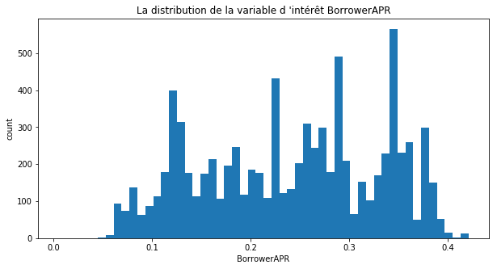

## Graphique corrélation entre BorrowerAPR et LenderYield

> Le Taux d'intérêt de l'emprunteur et le rendement du préteur ont une forte corrélation positive , c'est à dire plus le taux d'intérêt de l'emprunteur augmente plus le rendement du préteur est grande.

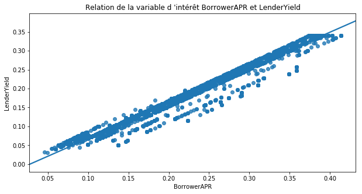

## Diagramme de vilion entre BorrowerAPR et IncomeRange

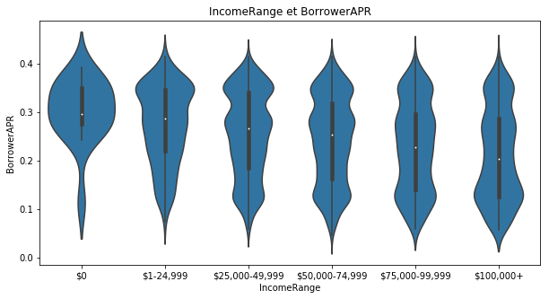

## Diagramme de boites à moustaches LoanStatus BorrowerAPR pour chaque plage de salaire

> Pour chaque plage de salaire ceux qui ont le taux d'apr le plus bas sont ceux qui ont une fois tout complétement complété leurs prets , pour ceux qui perçoivent dans l'année entre 1 et 24,999 dollars se voient avoir des taux d'intéret plus bas s'ils un défaut sur leurs paiements .

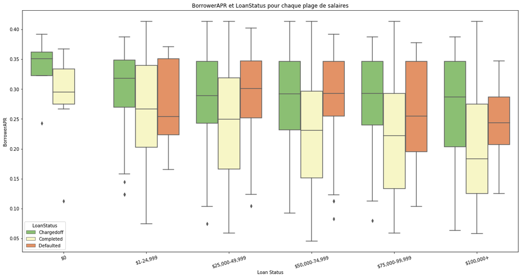